# Scrublet: Doublet remover

https://nbviewer.jupyter.org/github/AllonKleinLab/scrublet/blob/master/examples/scrublet_basics.ipynb

https://github.com/AllonKleinLab/scrublet

```python
%matplotlib inline
import scrublet as scr
import scipy.io
import matplotlib.pyplot as plt
import numpy as np
import os

plt.rcParams['font.family'] = 'sans-serif'
plt.rcParams['font.sans-serif'] = 'Arial'
plt.rc('font', size=14)
plt.rcParams['pdf.fonttype'] = 42
```

## Download and load data

```python
!wget http://cf.10xgenomics.com/samples/cell-exp/2.1.0/pbmc8k/pbmc8k_filtered_gene_bc_matrices.tar.gz
!tar xfz pbmc8k_filtered_gene_bc_matrices.tar.gz
```

```
--2020-06-09 17:30:20--  http://cf.10xgenomics.com/samples/cell-exp/2.1.0/pbmc8k/pbmc8k_filtered_gene_bc_matrices.tar.gz
cf.10xgenomics.com (cf.10xgenomics.com) をDNSに問いあわせています... 54.230.175.79, 54.230.175.52, 54.230.175.112, ...
cf.10xgenomics.com (cf.10xgenomics.com)|54.230.175.79|:80 に接続しています... 接続しました。
HTTP による接続要求を送信しました、応答を待っています... 200 OK
長さ: 37558165 (36M) [application/x-tar]
`pbmc8k_filtered_gene_bc_matrices.tar.gz.1' に保存中

pbmc8k_filtered_gen 100%[===================>]  35.82M  11.2MB/s    時間 3.2s

2020-06-09 17:30:23 (11.2 MB/s) - `pbmc8k_filtered_gene_bc_matrices.tar.gz.1' へ保存完了 [37558165/37558165]
```

```python
input_dir = 'filtered_gene_bc_matrices/GRCh38/'
counts_matrix = scipy.io.mmread(input_dir + '/matrix.mtx').T.tocsc()
genes = np.array(scr.load_genes(input_dir + 'genes.tsv', delimiter='\t', column=1))

print('Counts matrix shape: {} rows, {} columns'.format(counts_matrix.shape[0], counts_matrix.shape[1]))
print('Number of genes in gene list: {}'.format(len(genes)))
```

```
Counts matrix shape: 8381 rows, 33694 columns
Number of genes in gene list: 33694
```

```python
counts_matrix
```

```
<8381x33694 sparse matrix of type '<class 'numpy.longlong'>'
	with 11788294 stored elements in Compressed Sparse Column format>
```

```python
genes
```

```
array(['RP11-34P13.3', 'FAM138A', 'OR4F5', ..., 'AC240274.1',
       'AC213203.1', 'FAM231B'], dtype='<U19')
```

## Initialize Scrublet object

- 関連するパラメータ:
  - expected_doublet_rate: ダブレットの割合の期待値。通常は0.05-0.1。得られる結果はこのパラメータに特に敏感ではありません。
    - この例では、期待されるダブレット率は[Chromiumユーザーガイド](https://support.10xgenomics.com/permalink/3vzDu3zQjY0o2AqkkkI4CC) から引用しています。
  - sim_doublet_ratio: シミュレーションするダブレットの数（観測されたトランスクリプトームの数に対する）。この値は、すべてのダブレット状態がシミュレートされたダブレットによって十分に表現されるように十分に高くなければなりません。
    - 高すぎる設定は計算コストがかかります。デフォルト値は2ですが、0.5以下の値を設定しても、テストしたデータセットでは非常に似たような結果が得られます。
  - n_neighbors. observed transcriptomes と simulated doubletsを分類するKNN分類器のKの値。`round(0.5*sqrt(n_cells))` のデフォルト値が一般的によく機能します。

```python
scrub = scr.Scrublet(counts_matrix, expected_doublet_rate = 0.06)
```

デフォルトのパイプラインを実行します。これには以下を含みます:

- Doublet simulation
- 正規化、遺伝子フィルタリング、スケーリング、PCA
- ダブレットスコア計算
- ダブレットスコアの閾値検出とダブレットの同定

```python
doublet_scores, predicted_doublets = scrub.scrub_doublets(min_counts=2,
                                                          min_cells=3,
                                                          min_gene_variability_pctl=85,
                                                          n_prin_comps=30)
```

```
Preprocessing...
Simulating doublets...
Embedding transcriptomes using PCA...
Calculating doublet scores...
Automatically set threshold at doublet score = 0.22
Detected doublet rate = 4.4%
Estimated detectable doublet fraction = 61.1%
Overall doublet rate:
	Expected   = 6.0%
	Estimated  = 7.2%
Elapsed time: 10.5 seconds
```

## Plot doublet score histograms for observed transcriptomes and simulated doublets

- シミュレートされたダブレットヒストグラムは、典型的には二峰性です。
  - 左のモードは、類似の遺伝子発現を持つ2つの細胞によって生成された "埋め込まれた"ダブレットに対応しています。
  - 右のモードは、異なる遺伝子発現を持つ細胞（例えば、異なる細胞タイプ）によって生成された「ネオタイプ」ダブレットに対応しており、下流の解析ではより多くのアーチファクトが発生すると予想されます。
  - Scrubletは、ネオタイプのダブレットのみを検出することができます。
- ダブレット vs. シングルレットを分類するためには、シミュレートされたダブレットヒストグラムにおいて2つのモードの間のlocal minimum である閾値を設定しなければなりません。
- 自動閾値検出がうまくいかない場合は、`call_doublets()` 関数でしきい値を調整することができます。例えば、`scrub.call_doublets(threshold=0.25)` のようになります。

[output not shown]

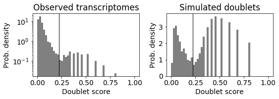

```python
scrub.plot_histogram()
```

## Plot doublet predictions on 2-D embedding

予測されたダブレットは、異なる状態で共局在しているはずです。

```python
scrub.set_embedding('UMAP', scr.get_umap(scrub.manifold_obs_, 10, min_dist=0.3))

# # Uncomment to run tSNE - slow
# print('Running tSNE...')
# scrub.set_embedding('tSNE', scr.get_tsne(scrub.manifold_obs_, angle=0.9))

# # Uncomment to run force layout - slow
# print('Running ForceAtlas2...')
# scrub.set_embedding('FA', scr.get_force_layout(scrub.manifold_obs_, n_neighbors=5. n_iter=1000))
```

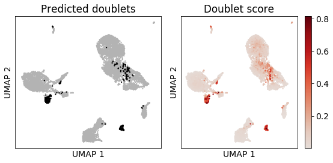

```python
scrub.plot_embedding('UMAP', order_points=True);

# scrub.plot_embedding('tSNE', order_points=True);
# scrub.plot_embedding('FA', order_points=True);
```

Best practices:

- 複数のサンプルからのデータを扱う場合は、各サンプルを別々にScrubletを実行してください。Scrubletは2つの細胞のランダムな共カプセル化によって形成された技術的なダブレットを検出するように設計されているため、細胞タイプの割合が単一のサンプルを代表するものではないマージされたデータセットでは、パフォーマンスが低下することがあります。
- ダブレットスコアのしきい値が妥当であることをチェックして（理想的なケースでは、この例のように、バイモーダルなシミュレートされたダブレットスコアヒストグラムの2つのピークを分離する）、必要に応じて手動で調整してください。
- 2次元埋め込み（例えば、UMAPまたはt-SNE）でダブレット予測を可視化します。予測されたダブレットは、ほとんどが共局在しているはずです（複数のクラスター内にある場合もあります）。もしそうでない場合は、ダブレットスコアのしきい値を調整するか、前処理のパラメータを変更して、データに存在する細胞の状態をより良く解決する必要があるかもしれません。

## Appendix：任意の10Xデータに適用するための関数

```python
import scrublet as scr
import scipy.io
import matplotlib.pyplot as plt
import numpy as np

def CallScrublet(input_dir):
    import warnings
    warnings.filterwarnings('ignore')
    counts_matrix = scipy.io.mmread(input_dir + '/matrix.mtx').T.tocsc()
    genes = np.array(scr.load_genes(input_dir + 'genes.tsv', delimiter='\t', column=1))
    print('Counts matrix shape: {} rows, {} columns'.format(counts_matrix.shape[0], counts_matrix.shape[1]))
    print('Number of genes in gene list: {}'.format(len(genes)))
    scrub = scr.Scrublet(counts_matrix, expected_doublet_rate = 0.06)
    doublet_scores, predicted_doublets = scrub.scrub_doublets(min_counts=2,
                                                          min_cells=3,
                                                          min_gene_variability_pctl=85,
                                                          n_prin_comps=30)
    scrub.plot_histogram()
    print('Number of doublets: {}'.format(np.sum(predicted_doublets)))
    scrub.set_embedding('UMAP', scr.get_umap(scrub.manifold_obs_, 10, min_dist=0.3))
    scrub.plot_embedding('UMAP', order_points=True)

    return scrub, predicted_doublets
```

```
Counts matrix shape: 8381 rows, 33694 columns
Number of genes in gene list: 33694
Preprocessing...
Simulating doublets...
Embedding transcriptomes using PCA...
Calculating doublet scores...
Automatically set threshold at doublet score = 0.22
Detected doublet rate = 4.4%
Estimated detectable doublet fraction = 61.1%
Overall doublet rate:
	Expected   = 6.0%
	Estimated  = 7.2%
Elapsed time: 9.1 seconds
Number of doublets: 367
```

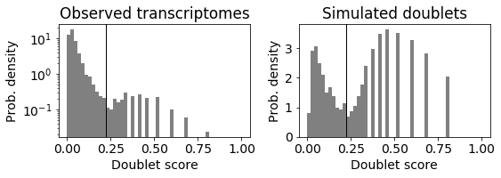

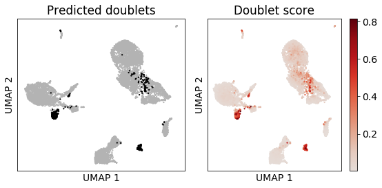

```python
scrub, predicted_doublets = CallScrublet('filtered_gene_bc_matrices/GRCh38/')
```